# Assignment 11: Detecting Overfitting and Overfitting Issues

Josie Gallop

Due: 04-14-2026

## **Assignment Objectives**

- Enhance understanding the procedure of likelihood-based chi-square hypothesis testing .
- Implement the procedures for detecting overfitting/underfitting issues in practical applications.

## **Policies of Using AI Tools**

**Policy on AI Tool Use**: Please adhere to the AI tool policy specified in the course syllabus. The direct copying of AI-generated content is strictly prohibited. All submitted work must reflect your own understanding; where external tools are consulted, content must be thoroughly rephrased and synthesized in your own words.

**Code Inclusion Requirement**: Any code included in your essay must be properly commented to explain the purpose and/or expected output of key code lines. Submitting AI-generated code without meaningful, student-added comments will not be accepted.

## Testing Overfitting/Underfitting

In Machine Learning and Statistics, overfitting occurs when a model is too complex and learns noise, leading to poor performance on new data, while underfitting happens when a model is too simple to capture important patterns, resulting in high errors overall; both issues are explained by the Bias–Variance Tradeoff and can cause unreliable predictions in real-world applications.

The probability density function (PDF) of the Weibull distribution is:

$$f(t; \lambda, \beta) = \frac{\beta}{\lambda} \left( \frac{t}{\lambda}
\right)^{\beta-1} \exp\left[ -\left( \frac{t}{\lambda} \right)^\beta
\right], \quad t \ge 0$$
where $\lambda > 0$ is the scale parameter (characteristic life) and $\beta > 0$ is the shape parameter.

When $\beta = 1$, the Weibull PDF simplifies to the exponential PDF:

$$f(t; \lambda) = \frac{1}{\lambda} \exp\left( -\frac{t}{\lambda} \right)$$
with constant hazard rate $h(t) = 1/\lambda$.

**This assignment focuses on performing a hypothesis test for the shape parameter ($\beta$) of the Weibull distribution within a reliability mode**

$$\begin{align}
H_0&: \beta = 1 \quad \text{(Exponential model, simpler)} \\
H_1&: \beta \neq 1 \quad \text{(Weibull model, more complex)}
\end{align}$$

## **Question: Reliability Application**

A mid-sized manufacturing company producing industrial conveyor systems began experiencing unexpected downtime in one of its distribution facilities, prompting concern about the reliability of a newly sourced batch of ball bearings used in the motor assemblies. These bearings, supplied by a vendor adopting cost-saving production methods, were installed across multiple units operating under continuous load conditions. After several months, maintenance logs revealed a pattern of increasing failures, with components lasting anywhere from a few dozen to over 150 hours before breakdown. To investigate, the engineering team collected time-to-failure data from 50 identical bearings and conducted a Weibull analysis within the framework of Reliability Engineering. The 50 time-to-failure (survival time) are:

```
12.4, 18.7, 25.3, 30.1, 33.5, 35.2, 38.9, 40.3, 42.7, 45.1, 47.6, 49.8, 52.4, 55.0,
57.3, 60.2, 62.8, 65.1, 67.9, 70.5, 72.3, 75.6, 78.2, 80.9, 83.4, 85.7, 88.1, 90.6,
93.2, 95.8, 98.4, 101.0, 104.5, 107.3, 110.6, 113.2, 116.8, 120.1, 123.7, 127.4,
130.9, 134.5, 138.2, 142.0, 146.3, 150.7, 155.2, 160.8, 168.4, 175.9
```

This assignment focuses on hypothesis $H_0: \beta = 1$ (exponential) against $H_1: \beta \neq 1$ (Weibull). This framework detects overfitting (fitting a Weibull when exponential is true) and underfitting (fitting exponential when Weibull with $\beta \neq 1$ is true).

a). Find the MLE of the Weibull parameters $\lambda$ (scale) and $\beta$ (shape), denoted by $\hat{\lambda}$ and $\hat{\beta}$, respectively, using the `optim()` procedure. [*Hint: You should provide explicit expressions for the log-likelihood and gradient functions of the Weibull distribution parameters.*]

First, I will begin with creating a data set for the time to failure information. This data set contains 50 observations, and these observations represent 50 identical bearings of maintenance log failure times. I will call the data set “time”.

```r
time <- c(12.4, 18.7, 25.3, 30.1, 33.5, 35.2, 38.9, 40.3, 42.7, 45.1, 47.6, 49.8, 52.4, 55.0, 57.3, 60.2, 62.8, 65.1, 67.9, 70.5, 72.3, 75.6, 78.2, 80.9, 83.4, 85.7, 88.1, 90.6, 93.2, 95.8, 98.4, 101.0, 104.5, 107.3, 110.6, 113.2, 116.8, 120.1, 123.7, 127.4,130.9, 134.5, 138.2, 142.0, 146.3, 150.7, 155.2, 160.8, 168.4, 175.9)

n <- length(time)
```

Now that the data has been stored in a data set, the next step is to find the MLE of the Weibull parameters $\hat{\lambda}$ and $\hat{\beta}$ using the optim() R function. I will create an R function using optim() to find these Weibull parameters.

I know that the PDF of the Weibull distribution is as follows: $f(t;\lambda,\beta)=\frac{\beta}{\lambda}\left(\frac{t}{\lambda}\right)^{\beta-1}\exp\left[-\left(\frac{t}{\lambda}\right)^\beta\right], \quad t \ge 0$

So, the log-likelihood function for this Weibull distribution would be: $\ell(\lambda,\beta)=n\log\beta - n\beta\log\lambda + (\beta-1)\sum_{i=1}^n \log t_i - \sum_{i=1}^n \left(\frac{t_i}{\lambda}\right)^\beta$

The gradient functions for the Weibull parameters, $\lambda$ and $\beta$, are as given below.

First, for $\lambda$: $\frac{\partial \ell}{\partial \lambda} = -\frac{n\beta}{\lambda} + \frac{\beta}{\lambda} \sum_{i=1}^n \left(\frac{t_i}{\lambda}\right)^\beta$

Next, for $\beta$: $\frac{\partial \ell}{\partial \beta} = \frac{n}{\beta} - n\log\lambda + \sum_{i=1}^n \log t_i - \sum_{i=1}^n \left(\frac{t_i}{\lambda}\right)^\beta \log\left(\frac{t_i}{\lambda}\right)$

I will use these gradients as well as the overall log likelihood function for the Weibull distribution in making my R function.

```r
# Log-likelihood
loglik_weibull <- function(par){
  lambda <- par[1]
  beta <- par[2]
  if(lambda <= 0 || beta <= 0) return(Inf)

  ll <- n*log(beta) - n*beta*log(lambda) +
        (beta-1)*sum(log(time)) -
        sum((time/lambda)^beta)
  return(-ll)
}

# Gradient functions
grad_weibull <- function(par){
  lambda <- par[1]
  beta <- par[2]

  term <- (time/lambda)^beta

  # Beta
  d_beta <- n/beta - n*log(lambda) + sum(log(time)) -
            sum(term * log(time/lambda))
  #Lambda
  d_lambda <- -n*beta/lambda + (beta/lambda)*sum(term)

  return(-c(d_lambda, d_beta))
}

# Optim() function
fit_weibull <- optim(c(100,1), loglik_weibull, grad_weibull,
                     method="BFGS", hessian=TRUE)

lambda_hat <- fit_weibull$par[1]
beta_hat <- fit_weibull$par[2]

lambda_hat
```

```
[1] 99.04056
```

```r
beta_hat
```

```
[1] 2.206286
```

It turns out that $\hat{\lambda}$ = 99.04 and $\hat{\beta}$ = 2.21.

b). Find the MLE of the exponential parameter $\lambda$ (scale), denoted by $\hat{\lambda}$, using any procedure. [*Hint: You should provide explicit expressions for the log-likelihood and gradient functions of the exponential distribution parameters.*]

I will find the MLE of the exponential parameter $\lambda$, denoted by $\hat{\lambda}$. I know that the PDF for an exponential distribution is as follows:

$f(t;\lambda)=\frac{1}{\lambda} e^{-t/\lambda}, \quad t \ge 0$

The log likelihood function for this exponential distribution is: $\ell(\lambda) = -n \log \lambda - \frac{1}{\lambda} \sum_{i=1}^n t_i$

So, the MLE for $\hat{\lambda}$ is: $\hat{\lambda} = \bar{t} = \frac{1}{n} \sum_{i=1}^n t_i$.

I will use this information to find the $\hat{\lambda}$ parameter for the time information. First, I will manually calculate this parameter using the gradients and log likehood function, like how I did in part a. Then, I will verify this by calculating the mean of time, as I know that the MLE parameter for an exponential distribution must equal the mean of the data.

```r
# Log-likelihood
loglik_exp <- function(lambda){
  if(lambda <= 0) return(Inf)
  ll <- -n*log(lambda) - sum(time)/lambda
  return(-ll)
}

# Gradient function
grad_exp <- function(lambda){
  grad <- -(-n/lambda + sum(time)/lambda^2)
  return(grad)
}

# Optim() function
fit_exp <- optim(par=100, fn=loglik_exp, gr=grad_exp,
                 method="BFGS", hessian=TRUE)

lambda_exp_hat_optim <- fit_exp$par
lambda_exp_hat_optim
```

```
[1] 87.61088
```

It turns out that $\hat{\lambda}$ = 87.61. I will verify this by finding the mean of the time data. This should give the same result as I know that $\hat{\lambda} = \bar{t}$ for an exponential distribution.

```r
lambda_exp_hat <- mean(time)
lambda_exp_hat
```

```
[1] 87.61
```

Again I get that $\hat{\lambda}$ = 87.61, meaning that my R function was accurate in finding the MLE of the exponential parameter.

c). Perform the likelihood ratio $\chi^2$ test on $\beta = 1$. What is the p-value? [*Hint: Use the results in a) and b)*.]

I will perform the likelihood ratio $\chi^2$ test on $\beta = 1$. For this test, the test statistic is $\Lambda = -2\left(\ell_{H_0} - \ell_{H_1}\right)$. It will be tested whether it is true that $\beta = 1$ or if $\beta$ significantly differs from 1. If it is true that $\beta$ significantly differs from 1, then the Weibull model would be prefered. The Weibull model is the more complex model. If it turns that $\beta$ does not differ from 1, then the more simpler Exponential model would be preferred.

The hypotheses are as follows:

$H_0: \beta = 1 \quad \text{(Exponential model)}$

$H_1: \beta \neq 1 \quad \text{(Weibull model)}$

Under the null hypothesis, $\Lambda \sim \chi^2_1$. An R function will be created the find the likelihood ratio test statistic, and test whether it is statistically significant by finding its p-value. An $\alpha$ = 0.05 significance level will be used.

```r
# Log-likelihood functions
loglik_exp <- function(lambda){
  -n*log(lambda) - sum(time)/lambda
}

ll_exp <- loglik_exp(lambda_exp_hat)
ll_weibull <- -fit_weibull$value

# Likelihood ratio test statistic
LR <- -2*(ll_exp - ll_weibull)

# p-value
p_value_LR <- 1 - pchisq(LR, df=1)

LR
```

```
[1] 34.44995
```

```r
p_value_LR
```

```
[1] 4.373551e-09
```

d). Perform the Wald $\chi^2$ on the same hypothesis $\beta = 1$. What is the p-value? [*Hint: You need to find the observed Fisher information matrix (i.e., the negative Hessian matrix from `optim()`) based on the Weibull distribution. The inverse of the observed Hessian matrix is the covariance matrix*.]

Next, I will perform the Wald $\chi^2$ test on the same hypothesis of $\beta = 1$. Like in part c, I will test whether or not $\beta$ significantly differs from 1. This time I will use the Wald test. I know that the Wald test statistic is $W = \frac{(\hat{\beta} - 1)^2}{\mathrm{Var}(\hat{\beta})}$. Additionally, $W \sim \chi^2_1$.

The hypotheses are as follows:

$H_0: \beta = 1 \quad \text{(Exponential model)}$

$H_1: \beta \neq 1 \quad \text{(Weibull model)}$

I will write an R function which begins with finding the covariance matrix. This will be the inverse of the negative observed Hessian matrix. This function will then find the Wald test statistic and its p-value.

```r
# Covariance matrix
cov_mat <- solve(fit_weibull$hessian)
var_beta <- cov_mat[2,2]

# Wald test statistic
W <- (beta_hat - 1)^2 / var_beta

# p-value
p_value_Wald <- 1 - pchisq(W, df=1)

W
```

```
[1] 23.11823
```

```r
p_value_Wald
```

```
[1] 1.523394e-06
```

e). Write a summary of the above analyses to address the following:

- Whether the two tests generated the same results.
- Which model is recommended for the data.
- Draw the density curve based on the MLE(s) of the parameter(s) and describe the distribution of the time-to-failure.

Both a likelihood ratio test and a Wald test were conducted on the same hypothesis of $\beta = 1$. A hypothesis test of whether $\beta$ truly differed from 1 was conducted using both methods. Both tests resulted in statistically significant p-values of p < .001. This means that the conclusions for both tests were indeed the same, and gave the same resulted. Both tests gave information to say that the null hypothesis should be rejected, and thus, we should conclude that there is significant evidence that $\beta$ truly differs from 1. This agreement between the two tests strengthens confidence in this conclusion to reject the null hypothesis.

As the conclusion was to reject the null hypothesis, there is sufficient evidence to conclude that $\beta \neq 1$. This means that the Exponential model is not sufficient for this data. The exponential model is the simpler model, and would be selected if we failed to reject the null hypothesis. However, we found that we should indeed reject the null hypothesis, so the exponential model would not be the adequate choice for this data.

Instead, the conclusion means that the Weibull model would be the best choice for this data, as backed up by both the likelihood ratio test results and the Wald test results. Therefore, the Weibull model should be selected for this data. The Weibull model would provide a more flexible fit for the failure rate, as opposed to the Exponential model which would assume a constant failure rate. A flexible failure rate is more appropriate in the practical context of this data. Therefore, the Weibull model is the better choice.

A density curve will be drawn based on the MLEs of the parameters that were found.

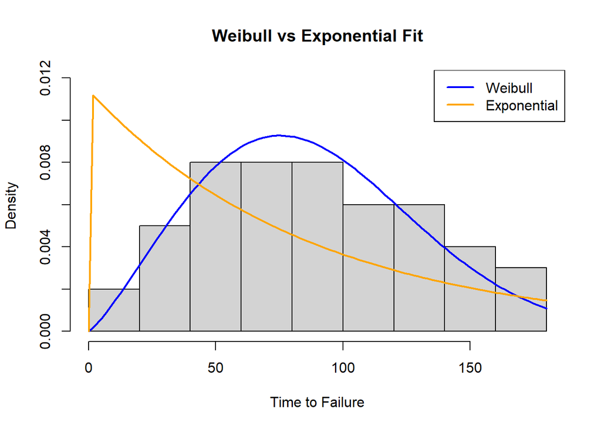

```r
# Histogram
hist(time, probability = TRUE, col = "lightgray", breaks = 10,
     main = "Weibull vs Exponential Fit",
     xlab = "Time to Failure",
     ylim = c(0, max(dweibull(time, shape = beta_hat, scale = lambda_hat),
                    dexp(time, rate = 1/lambda_exp_hat)) * 1.2))

# Weibull
curve(dweibull(x, shape=beta_hat, scale=lambda_hat),
      col="blue", lwd=2, add=TRUE)

# Exponential
curve(dexp(x, rate=1/lambda_exp_hat),
      col="orange", lwd=2, add=TRUE)

legend("topright",
       legend=c("Weibull","Exponential"),
       col=c("blue","orange"), lwd=2)
```

As seen in the plot, the Weibull curve follows what appears to be a slightly skewed right distribution. The Exponential curve follows a very extremely skewed to the right distribution. The distribution of the time to failure data follows a slightly skewed to the right distribution. This distribution appears to have a right tail, extending out to the higher failure times. The Weibull curve manages to capture this distribution better, by matching the slight skew as opposed to the severe skewness of the Exponential curve.

The Weibull density curve follows a much more accurate fit to the observed distribution of the failure times, and is much more accurate to this distribution than the Exponential density curve. Therefore, this matches up with the conclusion of the Weibull model being the better choice for this data than the Exponential model.

While the tests on the two models both gave statistically significant results, it is clear that the Weibull model is the better choice. The Weibull density curve is a much better fit for the data’s distribution than the Exponential density curve is, as seen in the above plot. Additionally, the more complex Weibull model is able to better capture a non-constant failure rate, which provides a better and more detailed fit for the model, which enhances its accuracy. Overall, the Weibull model is the best choice for this failure time data.